# AS04_Visualizing_Visualizing-Date-Time

楊紫希 60988016i 師大大傳

2022/04/14

## 作業目的: Data Visualization (01) Datetime

這份作業希望能夠讓你熟悉於處理日期與時間資料，並且利用視覺化的文法(grammar of graphics) 呈現結果。過程中會用到前幾週學過 dplyr 的動詞，以及 lubridate 和 ggplot2。每個小題都請寫下你的原始碼並且畫出圖表。

這次的作業使用 readr 提供的[原始資料](https://github.com/readr-media/readr-data/tree/master/movie_tickets)，主題是台灣的電影票房，有興趣的話可以點進 [【數讀國片票房】全球影視寒冬，2020 臺灣電影如何逆勢崛起](https://www.readr.tw/post/2522) 看一下這篇資料新聞。每一個小題都是新聞上的一張圖表！

## 作業: Data Visualization (01) Datetime

```r
### 這邊不要動
library(tidyverse)
library(lubridate)
library(ggthemes)

df_movie_raw <- read_csv("data/AS04/movie_tickerts_2017_2020.csv")
### 給你看資料長這樣
df_movie_raw %>% glimpse()
```

```
#> Rows: 15,704
#> Columns: 16
#> $ name         <chr> "全國電影票房2017年10021008統計資訊", "全國電影票房2017年…
#> $ 國別地區     <chr> "中國大陸", "中華民國", "中華民國", "香港", "中華民國", "…
#> $ 中文片名     <chr> "我在故宮修文物", "乒乓", "林投記", "追龍", "老師你會不會…
#> $ 上映日期     <date> 2017-10-02, 2017-10-02, 2017-10-02, 2017-09-29, 2017-09-…
#> $ 申請人       <chr> "岸上影像有限公司", "財團法人公共電視文化事業基金會", "財…
#> $ 出品         <chr> "杭州潛影文化創意有限公司##故宮博物院##天津貓眼文化傳媒有…
#> $ 上映院數     <dbl> 9, 1, 1, 67, 78, 58, 81, 10, 5, 10, 8, 3, 5, 3, 7, 4, 4, …
#> $ 銷售票數     <dbl> 570, 295, 275, 86861, 52922, 26034, 16119, 3101, 1253, 10…
#> $ 銷售金額     <dbl> 129103, 58250, 54130, 19872900, 11852483, 5918703, 371839…
#> $ 累計銷售票數 <dbl> 616, 382, 354, 136853, 100844, 45571, 31218, 4993, 1915, …
#> $ 累計銷售金額 <dbl> 136143, 75340, 69440, 31110909, 22419756, 10319396, 71809…
#> $ end_date     <date> 2017-10-08, 2017-10-08, 2017-10-08, 2017-10-08, 2017-10-…
#> $ year         <dbl> 2017, 2017, 2017, 2017, 2017, 2017, 2017, 2017, 2017, 201…
#> $ start_date   <date> 2017-10-02, 2017-10-02, 2017-10-02, 2017-10-02, 2017-10-…
#> $ end_year     <dbl> 2017, 2017, 2017, 2017, 2017, 2017, 2017, 2017, 2017, 201…
#> $ screen_year  <dbl> 2017, 2017, 2017, 2017, 2017, 2017, 2017, 2017, 2017, 201…
```

### 1. `geom_line()`:

請參考 readr 的圖表，畫出台灣 2017/10 ~ 2020/11 每週的放映數量，並且用不同顏色的曲線表示年份，其中 2020 年的曲線以實線表示，2017 - 2019 年的曲線則以虛線(dotted line)表示。

可以參考 data -> AS04 -> plot_01.jpg，或者直接看 readr 報導當中標題為「臺灣電影每週放映數量」的圖表。因為週次計算方式可能有差異，因此不要求和 readr 計算出的數字完全相同，呈現類似趨勢即可。週次的計算方式可以挑選 **`start_date`** 作為基準。

keywords： `geom_line()`, `week()`, `color = ?`, `linetype = ?`

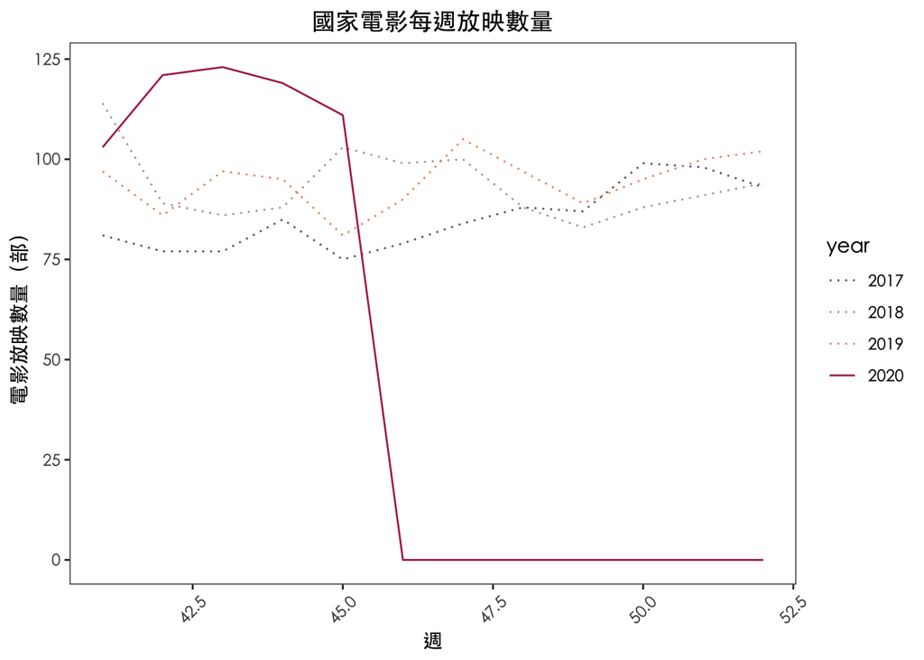

```r
### your code
df2017 <- df_movie_raw %>%
  mutate(newdate = as.POSIXct(strptime(start_date,"%Y-%m-%d"))) %>%
  filter(newdate >= as_datetime("2017-10-8") & newdate <= as_datetime("2020-11-15")) %>%
  mutate(wd = week(newdate)) %>%
  select(newdate,wd,year) %>%
  filter(year == 2017) %>%
  group_by(wd) %>%
  summarise(nwd2017 = n()) %>%
  ungroup()

df2018 <- df_movie_raw %>%
  mutate(newdate = as.POSIXct(strptime(start_date,"%Y-%m-%d"))) %>%
  filter(newdate >= as_datetime("2017-10-8") & newdate <= as_datetime("2020-11-15")) %>%
  mutate(wd = week(newdate)) %>%
  select(newdate,wd,year) %>%
  filter(year == 2018) %>%
  group_by(wd) %>%
  summarise(nwd2018 = n()) %>%
  ungroup()

df2019 <- df_movie_raw %>%
  mutate(newdate = as.POSIXct(strptime(start_date,"%Y-%m-%d"))) %>%
  filter(newdate >= as_datetime("2017-10-8") & newdate <= as_datetime("2020-11-15")) %>%
  mutate(wd = week(newdate)) %>%
  select(newdate,wd,year) %>%
  filter(year == 2019) %>%
  group_by(wd) %>%
  summarise(nwd2019 = n()) %>%
  ungroup()

df2020 <- df_movie_raw %>%
  mutate(newdate = as.POSIXct(strptime(start_date,"%Y-%m-%d"))) %>%
  filter(newdate >= as_datetime("2017-10-8") & newdate <= as_datetime("2020-11-15")) %>%
  mutate(wd = week(newdate)) %>%
  select(newdate,wd,year) %>%
  filter(year == 2020) %>%
  group_by(wd) %>%
  summarise(nwd2020 = n()) %>%
  ungroup()

df1718 <- left_join(df2017, df2018, by = "wd")
df171819<- left_join(df1718, df2019, by = "wd")
dffull <- left_join(df171819, df2020, by = "wd")
dffull[is.na(dffull)] <- 0


dffull %>%
  rename(`2017` = nwd2017,`2018` = nwd2018 , `2019` = nwd2019,`2020` = nwd2020 ) %>%
  pivot_longer(cols = `2017`:`2020`, names_to = "year", values_to = "n") %>%
  ggplot(aes(x = wd, y = n, fill = year , color = year)) +
  geom_line(aes(linetype=`year`)) +
  scale_linetype_manual(values=c("dotted","dotted","dotted","solid")) +
  scale_color_manual(values=c("dimgray","darkgray","darksalmon","maroon")) +
  theme_bw() +
  theme(panel.grid.major = element_blank(),
         panel.grid.minor = element_blank()) +
    labs(title = '國家電影每週放映數量', x = "週", y = "電影放映數量（部）") +
    theme(text=element_text(family="黑體-繁 中黑"),
    axis.text.x = element_text(angle = 45, vjust = 0.5),     # 解決中文亂碼問題
    plot.title = element_text(hjust = 0.5))
```

```r
### your result should be (參考)
#knitr::include_graphics('data/AS04/plot_01_ggplot.jpg')
#knitr::include_graphics('data/AS04/plot_01.jpg')
```

### 2. `geom_bar()` or `geom_col()`:

請參考 readr 的圖表，畫出台灣 2017 - 2020 每年所有電影票房與國片票房的長條圖，並以併排(dodge)方式呈現。

可以參考 data -> AS04 -> plot_02.jpg，或者直接看 readr 報導當中標題為「臺灣的電影銷售票房變化」的圖表。本題要求和 readr 的數字相同。年份的計算方式可以挑選 **`start_date`** 作為基準。

keywords： `geom_bar/col()`, `year()`, `fill = ?`

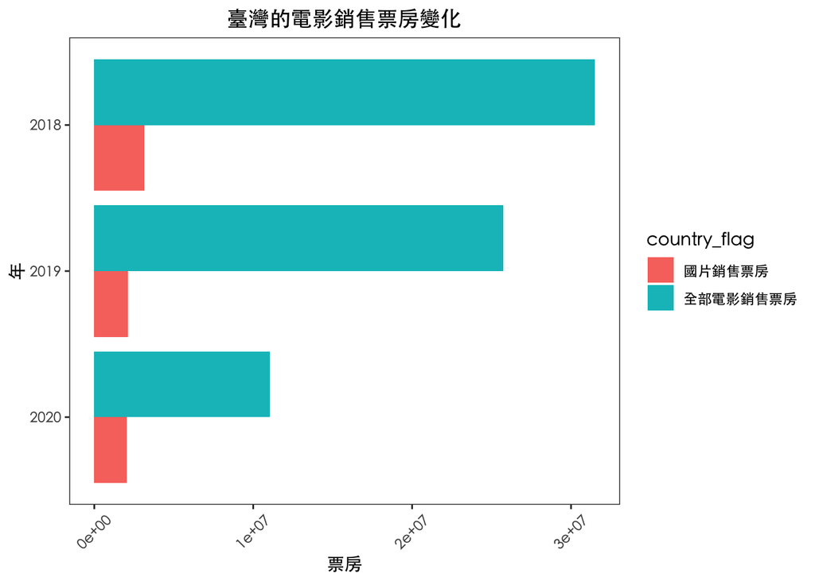

```r
### your code
df_movie_raw %>%
  filter(`國別地區` == "中華民國") %>%
  mutate(year = year(`start_date`)) %>%
  mutate(`中文片名` = str_remove_all(`中文片名`, " |　")) %>%
  mutate(`中文片名` = str_replace_all(`中文片名`, " ！", "!")) %>%
  group_by(year) %>%
  summarise(`銷售票數` = sum(`銷售票數`),
            `銷售金額` = sum(`銷售金額`)) %>%
  filter(year >= 2018) %>%
  ungroup() %>%
  mutate(country_flag = "國片銷售票房") %>%
  bind_rows(
    df_movie_raw %>%
      mutate(year = year(`start_date`)) %>%
      mutate(`中文片名` = str_remove_all(`中文片名`, " |　")) %>%
      mutate(`中文片名` = str_replace_all(`中文片名`, " ！", "!")) %>%
      group_by(year) %>%
      summarise(`銷售票數` = sum(`銷售票數`),
                `銷售金額` = sum(`銷售金額`)) %>%
      filter(year >= 2018) %>%
      ungroup() %>%
      mutate(country_flag = "全部電影銷售票房")
  ) %>%
  mutate(country_flag = fct_relevel(as.factor(country_flag), "國片銷售票房")) %>%
  mutate(year = fct_reorder(as.factor(year), desc(year))) %>%
  ggplot() +
  geom_col(aes(x = `銷售票數`, y = `year`,
           group = country_flag, fill = country_flag),
           position = "dodge") + theme_bw() +
  theme(panel.grid.major = element_blank(),
         panel.grid.minor = element_blank()) +
    labs(title = '臺灣的電影銷售票房變化', x = "票房", y = "年") +
    theme(text=element_text(family="黑體-繁 中黑"),
    axis.text.x = element_text(angle = 45, vjust = 0.5),
    plot.title = element_text(hjust = 0.5))
```

```r
### your result should be (參考)
#knitr::include_graphics('data/AS04/plot_02_ggplot.jpg')
#knitr::include_graphics('data/AS04/plot_02.jpg')
```

### 3. `geom_bar()` or `geom_col()`:

請參考 readr 的圖表，畫出台灣 2017 - 2020 每年國片上映院數的中位數長條圖。

可以參考 data -> AS04 -> plot_03.jpg，或者直接看 readr 報導當中標題為「國片上映院數是否有增加？」的圖表。本題要求和 readr 的數字相同。上映日期的計算方式可以直接使用 **`上映日期`** 欄位。

keywords： `geom_bar/col()`, `year()`, `fill = ?`

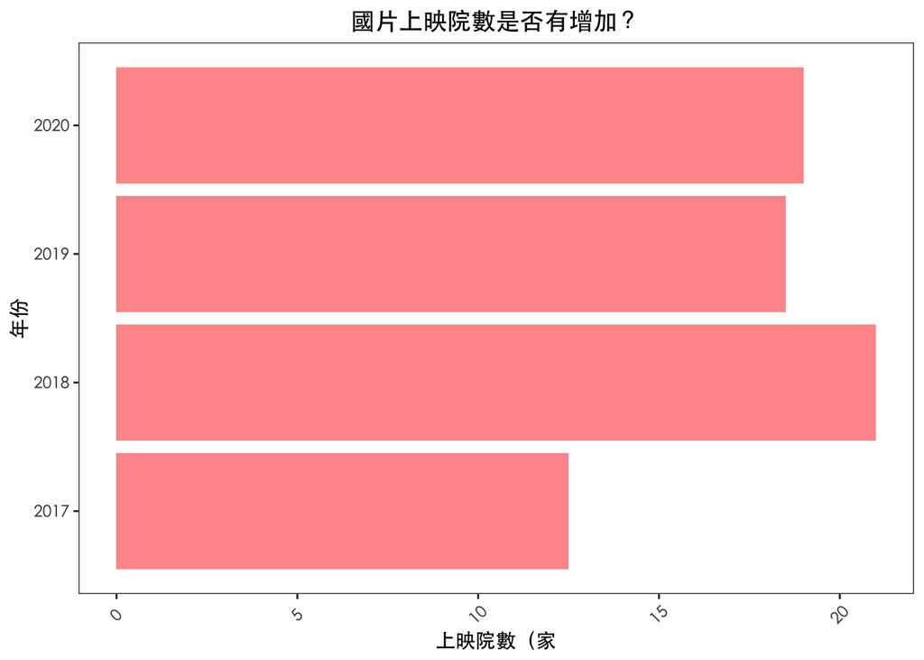

```r
### your code
df_movie_raw %>%
  mutate(year = year(`上映日期`)) %>%
  filter(`國別地區` == "中華民國" & `year` >=2017 & `year` <= 2020) %>%
  group_by(year, `中文片名`) %>%
  summarise(`上映院數` = max(`上映院數`)) %>%
  ungroup() %>%
  group_by(year)  %>%
  summarise(`國片上映院數中位數` = median(`上映院數`)) %>%
  ungroup() %>%
  ggplot(aes(x = `year`, y = `國片上映院數中位數`)) +
  geom_col(fill="#FF9999") +
  coord_flip() +
  theme_bw() +
  theme(panel.grid.major = element_blank(),
         panel.grid.minor = element_blank()) +
    labs(title = '國片上映院數是否有增加？', x = "年份", y = "上映院數（家") +
    theme(text=element_text(family="黑體-繁 中黑"),
    axis.text.x = element_text(angle = 45, vjust = 0.5),
    plot.title = element_text(hjust = 0.5))
```

[figure not shown]

```r
#mutate(type = ifelse(`國別地區` == "中華民國", "國片", "非國片")) %>%
#select(`中文片名`,`上映院數`, `year`,type) %>%


### your result should be (參考)
#knitr::include_graphics('data/AS04/plot_03_ggplot.jpg')
```

### 4. `geom_bar()` or `geom_col()`:

請參考 readr 的圖表，畫出台灣 2017 - 2020 國片累計銷售金額的長條圖，篩選出銷售金額前 23 高的國片後由大到小排列。（圖表中有部片叫做《可不可以，你也剛好喜歡我》，它是 2020 年上映的，readr 應該漏標了。）

可以參考 data -> AS04 -> plot_04.jpg，或者直接看 readr 報導當中標題為「2017 ~ 2020 熱賣國片前 20 名」的圖表。本題要求和 readr 的數字相同。上映日期的計算方式可以直接使用 **`上映日期`** 欄位。

keywords： `geom_bar/col()`, `year()`, `fill = ?`

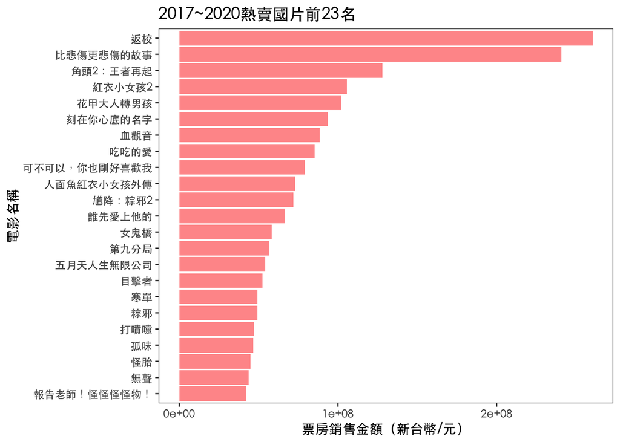

```r
### your code
df_movie_raw %>%
  mutate(`中文片名` = str_remove_all(`中文片名`, " |　")) %>%
  mutate(`中文片名` = str_replace_all(`中文片名`, " ！", "!")) %>%
  mutate(`上映日期` = as.POSIXct(strptime(`上映日期`,"%Y-%m-%d"))) %>%
  filter(`上映日期` >= as_datetime("2017-01-01") & `上映日期` <= as_datetime("2020-11-15")) %>%
  filter(`國別地區` == "中華民國") %>%
  select(year,`上映日期`,`中文片名`, `累計銷售金額`) %>%
  group_by(`中文片名`,) %>%
  summarise(`累計銷售金額` = max(`累計銷售金額`)) %>%
  arrange(desc(`累計銷售金額`)) %>%
  head(23) %>%
  arrange(desc(`累計銷售金額`)) %>%
  mutate(rank = row_number()) %>%
  mutate(`中文片名` = fct_reorder(as.factor(`中文片名`), desc(rank))) %>%
  ggplot() +
  geom_col(aes(x =`累計銷售金額`, y =`中文片名`),fill="#FF9999") +
  theme_bw() +
  theme(panel.grid.major = element_blank(),
         panel.grid.minor = element_blank()) +
    labs(title = '2017~2020熱賣國片前23名', x = "票房銷售金額（新台幣/元）", y = "電影名稱") +
    theme(text=element_text(family="黑體-繁 中黑"))
```

```r
### your result should be (參考)
#knitr::include_graphics('data/AS04/plot_04_ggplot.jpg')
#knitr::include_graphics('data/AS04/plot_04.jpg')
```